# A-21077-2021-09-23

by 21077

## Question

Exercises 5.4, 5.9, 5.13, and 5.14 (pages 149-151, Statistical Computating with R).

## Answer

### 5.4

Write a function to compute a Monte Carlo estimate of the Beta(3, 3) cdf, and use the function to estimate F(x)for x =0.1, 0.2,… , 0.9. Compare the estimates with the values returned by the pbeta function in R.

```r
beta_3_3_pdf <- function(x){
  x^2*(1-x)^2/beta(3,3)
}

beta_3_3_cdf <- function(x){
  m <- 10000
  u <- runif(m)
  mean(beta_3_3_pdf(u*x))*x
}
```

```r
est <- numeric(9)
true <- numeric(9)
for(i in c(1:9)){
  true[i] <- pbeta(i/10,3,3)
  est[i] <- beta_3_3_cdf(i/10)
}


knitr::kable(rbind(est,true,dif = est-true))
```

| est | 0.0085474 | 0.0585408 | 0.165028 | 0.3119241 | 0.4995373 | 0.6805351 | 0.8427222 | 0.9473116 | 0.9971875 |
| --- | --- | --- | --- | --- | --- | --- | --- | --- | --- |
| true | 0.0085600 | 0.0579200 | 0.163080 | 0.3174400 | 0.5000000 | 0.6825600 | 0.8369200 | 0.9420800 | 0.9914400 |
| dif | -0.0000126 | 0.0006208 | 0.001948 | -0.0055159 | -0.0004627 | -0.0020249 | 0.0058022 | 0.0052316 | 0.0057475 |

### 5.9

Implement a function to generate samples from a Rayleigh(σ) distribution, using antithetic variables. What is the percent reduction in variance?

```r
rayleigh_pdf <- function(x,sigma = 1) {
  ifelse(x>0, x/sigma^2*exp(-x^2/2/sigma^2), 0)
}
rayleigh_cdf <- function(x, sigma = 1, R = 10000, antithetic = TRUE) {
  if(x<=0) return(0)

  u <- runif(R/2)
  v <- ifelse(antithetic, 1-u, runif(R/2))
  u <- c(u, v)

  mean(rayleigh_pdf(x*u,sigma))*x
}
```

Verify the correctness of rayleigh_cdf with sigma = 1.

```r
x <- c(1:10) * 0.3
true <- numeric(10)
anti_MC <- numeric(10)
norm_MC <- numeric(10)

for(i in 1:10){
  true[i]    <-  integrate(rayleigh_pdf,0,x[i],abs.tol = 1e-5)$value
  anti_MC[i] <-  rayleigh_cdf(x[i],antithetic = TRUE)
  norm_MC[i] <-  rayleigh_cdf(x[i],antithetic = FALSE)
}

knitr::kable(rbind(x,true,anti_MC,norm_MC))
```

| x | 0.3000000 | 0.6000000 | 0.9000000 | 1.2000000 | 1.5000000 | 1.8000000 | 2.1000000 | 2.4000000 | 2.7000000 | 3.0000000 |
| --- | --- | --- | --- | --- | --- | --- | --- | --- | --- | --- |
| true | 0.0440025 | 0.1647298 | 0.3330232 | 0.5132477 | 0.6753475 | 0.8021013 | 0.8897495 | 0.9438652 | 0.9738786 | 0.9888910 |
| anti_MC | 0.0434108 | 0.1627842 | 0.3339038 | 0.5103265 | 0.6705002 | 0.7998603 | 0.8856854 | 0.9438818 | 0.9679186 | 0.9938692 |
| norm_MC | 0.0436603 | 0.1653222 | 0.3321860 | 0.5110855 | 0.6734668 | 0.8002533 | 0.8894020 | 0.9492872 | 0.9783357 | 0.9955425 |

compute the percent reduction in variance of rayleigh_cdf(x = 1, sigma = 1).

```r
R <- 100
anti_MC <- numeric(R)
norm_MC <- numeric(R)

for(i in 1:R){
  anti_MC[i] <-  rayleigh_cdf(1,antithetic = TRUE)
  norm_MC[i] <-  rayleigh_cdf(1,antithetic = FALSE)
}

v1 <- var(anti_MC)
v2 <- var(norm_MC)
cat("Var of antithetic method is ",v1,'.\n')
```

```
## Var of antithetic method is  5.522515e-06 .
```

```r
cat("Var of normal method is ",v2,'.\n')
```

```
## Var of normal method is  6.677624e-06 .
```

```r
cat("The percent reduction in variance is ",(v2- v1)/v2*100,"%.\n")
```

```
## The percent reduction in variance is  17.2982 %.
```

Generate samples by using cdf.

```r
# Inverse transform algorithm
rayleigh_sample <- function(n,sigma = 1, R = 10000, antithetic = TRUE){
  u <- runif(n)
  sam <- numeric(n)
  f <- function(x,c) rayleigh_cdf(x,sigma, R = R, antithetic = antithetic) - c

  for(i in c(1:n)){
    #sam[i] <- ifelse(f(1000,u[i])>0, uniroot(f,c(-0.1,1000),c=u[i])$root, 1000)
    sam[i] <- uniroot(f,c(-0.1,1000),c=u[i],extendInt = 'upX')$root
  }
  sam
}
```

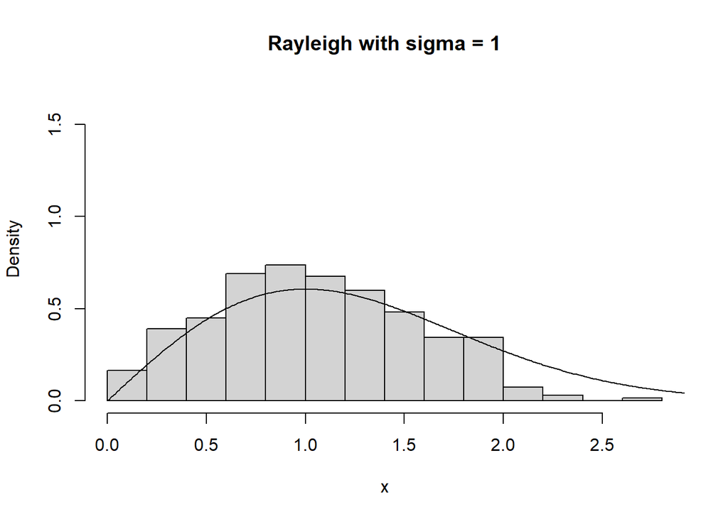

```r
n <- 400
x <- rayleigh_sample(n)
x <- x[which(x<10)]
hist(x,prob=TRUE,ylim=range(0,1/exp(-0.5)), main = "Rayleigh with sigma = 1")
y <- seq(0,floor(max(x))+1,0.01)
lines(y,rayleigh_pdf(y))
```

### 5.13

Find two importance functions f1 and f2 that are supported on {x>1} and are ‘close’ to g(x).

```r
g <- function(x){
  x^2*exp(-x^2/2)/(2*pi)^0.5
}
```

I choose normal distribution with mean=0 and sd=1 restricted in $(1,\infty)$ as f1 and chi-square distribution with df=6 restricted in $(1,\infty)$ as f2.

```r
f1 <- function(x){
  dnorm(x)/(1-pnorm(1))
}
f1_sample <- function(n){
  sam <- numeric(n)
  for(i in 1:n){
    sam[i] <- rnorm(1)
    while(sam[i]<=1){
      sam[i] <- rnorm(1)
    }
  }
  return(sam)
}
f2 <- function(x){
  dchisq(x,6)/(1-pchisq(1,6))
}
f2_sample <- function(n){
  sam <- numeric(n)
  for(i in 1:n){
    sam[i] <- rchisq(1,6)
    while(sam[i]<=1){
      sam[i] <- rchisq(1,6)
    }
  }
  return(sam)
}
```

Which of your two importance functions should produce the smaller variance?

I think f1 importance function produce the smaller variance, because $\frac{g(x)}{f_1(x)} \sim x^2$ is polynomial and $\frac{g(x)}{f_2(x)}\sim e^{\frac{x(1-x)}{2}}$ is exponential. This can be verified in the next question.

### 5.14

Obtain a Monte Carlo estimate by importance sampling.

```r
R <- 100
int_f1 <- numeric(R)
int_f2 <- numeric(R)

for(i in 1:R){
  n <- 100
  x1 <- f1_sample(n)
  x2 <- f2_sample(n)

  int_f1[i] <- mean(g(x1)/f1(x1))
  int_f2[i] <- mean(g(x2)/f2(x2))
}

cat("Use f1, the estimate is",mean(int_f1),"and the variance is",var(int_f1))
```

```
## Use f1, the estimate is 0.3990185 and the variance is 0.0007009215
```

```r
cat("Use f2, the estimate is",mean(int_f2),"and the variance is",var(int_f2))
```

```
## Use f2, the estimate is 0.416074 and the variance is 0.0101576
```